# Analisis problemas visuales en la Región Metropolitana

Manuel Astroza

2025-06-24

# Intoducción

La microsimulación es un método que permite relacionar variables disponibles a nivel comunal, como las que proporciona la Encuesta CASEN, para representarlas a un nivel más desagregado, como el de zona censal. Este proceso consiste en asignar o proyectar características individuales o de hogares observadas en la encuesta a unidades territoriales más pequeñas, aprovechando la información geográfica y sociodemográfica del censo. La microsimulación utiliza técnicas que pueden incluir el “matching” espacial, donde se emparejan observaciones de la encuesta con unidades del censo que comparten características similares, permitiendo así estimar variables en áreas con menor cobertura muestral y mayor detalle territorial.

Este método es especialmente útil cuando se desea obtener estimaciones más precisas y detalladas que las que se pueden obtener directamente de la encuesta, debido a limitaciones en el tamaño muestral o en la granularidad de los datos disponibles a nivel comunal.

# Justificación de la elección

La Región Metropolitana es la zona con mayor concentración poblacional y diversidad socioeconómica, lo que implica heterogeneidad en la prevalencia y acceso a servicios de salud visual.

Los problemas de vista son una condición de salud que afecta la calidad de vida y la productividad. En una región con tanta actividad de comercio y transporte es importante cuidar esta condición, pues problemas de visión pueden impactar a un menor rendimiento academico, laboral o bien repercutir en accidentes de tránsito.

La distribución puede variar significativamente dentro de la región, requiriendo un análisis detallado a nivel de zona censal para identificar áreas con mayores necesidades en donde la microsimulación permite captar esta heterogeneidad interna perdida analizar solo a nivel comunal facilitando el diseño de políticas públicas focalizadas en salud visual.

Así mismo, se realizará una comparativa con la variable edad, calculculando la taza de adultos mayores por zona censal, ya que muchos de estos suelen tener porblemas de visión, así mismo hacer esta distinción nos permitirá conocer si existen zonas en la cual la población joven sea más propensa a presentar estas dificultades.

# Area de estudio

Según proyecciones del Instituto Nacional de Estadísticas (INE) para 2025 la región tendrá 8.47 millones de habitantes aproximadamente, representando el 41.9% de la población total del país. La distribución por sexo es equilibrada, con un 50.5% mujeres y 49.5% hombres. En términos de edad, el 16.8% serán menores de 14 años, el 4.8% adolescentes (14-17 años), y un 18% adultos mayores (60 años o más), evidenciando una población con un importante segmento envejecido.

La Región Metropolitana es el principal motor económico del país, concentrando gran parte de la actividad productiva nacional. Destacan sectores como comercio, construcción, servicios profesionales, financieros e industria manufacturera. La región atrae inversiones públicas y privadas que impulsan el desarrollo urbano y económico generando oportunidades laborales diversas.

Los niveles de pobreza son relativamente bajos en comparación con el resto del país, pero con heterogeneidades internas. La pobreza por ingresos en algunas comunas es baja más la pobreza multidimensional (que considera acceso a educación, salud, vivienda y otros servicios) es más dispar ciertos sectores.

Considerando lo anterior se puede dividir geograficamente la región de la siguiente manera.

- Zona Centro: Suele concentrar actividades comerciales y administrativas, con ingresos variables, pero en general presenta un nivel medio de ingresos.
- Zona Norte: Tiene una mezcla de sectores industriales y residenciales, con ingresos que pueden ser medios a bajos.
- Zona Sur: Predominan sectores con ingresos medios a bajos, con mayor presencia de población con educación básica incompleta.
- Zona Este: Es la zona con mayores ingresos promedio, alta escolaridad y mejor acceso a servicios, caracterizada por un nivel socioeconómico alto.
- Zona Oeste: Presenta ingresos medios a bajos, con una mayor proporción de población con menor nivel educacional y mayor vulnerabilidad social.

# Desarrollo

Para realizar estre trabajo se consideran las siguientes librerias que permiten conectar con Postgres para una mejor consulta de datos, microsimular y generar mapas.

```r
# 1. Librerías
library(rakeR)
library(RPostgres) # Conexión postgres
library(DBI)
library(ggplot2)
library(biscale) # Mapa bivariado
library(cowplot)
library(sf)
```

El primer paso es leer las encuestas Cneso y CASEN y prepocesar los datos, con el fin de trabajar solo variables de interes por la magnitud de las mismas.

Además se define de manera bineria la variable de estudio según lo mencionado en la introducción.

```r
# 2. Entradas

## df del censo ya procesado
cons_censo_df <- readRDS("cons_censo_df.rds")
casen_raw = readRDS("casen_rm.rds")

# 3. Preprocesamiento

## 3.1 CENSO
col_cons   = sort(setdiff(names(cons_censo_df), c("GEOCODIGO","COMUNA")))
age_levels  = grep("^edad", col_cons, value = TRUE)
esc_levels  = grep("^esco", col_cons, value = TRUE)
sexo_levels = grep("^sexo_",col_cons, value = TRUE)

## 3.2 CASEN
vars_base = c("estrato", "esc", "edad", "sexo", "e6a", "h7a", "ypc")
casen = casen_raw[ , vars_base, drop = FALSE]
rm(casen_raw)

casen$Comuna = substr(as.character(casen$estrato), 1, 5)
casen$estrato = NULL

casen$esc = as.integer(unclass(casen$esc))
casen$edad = as.integer(unclass(casen$edad))
casen$e6a = as.numeric(unclass(casen$e6a))
casen$sexo = as.integer(unclass(casen$sexo))
casen$ypc = as.integer(unclass(casen$ypc))
casen$h7a = as.numeric(unclass(casen$h7a))
casen$h7a <- ifelse(casen$h7a == 1, 1, 0)  # 1 sano, 0 con problemas

idx_na = which(is.na(casen$esc))
fit = lm(esc ~ e6a, data = casen[-idx_na,])
pred = predict(fit, newdata = casen[idx_na, ,drop = FALSE])
casen$esc[idx_na] = as.integer(round(pmax(0, pmin(29, pred))))
casen$ID = as.character(seq_len(nrow(casen)))

casen$edad_cat <- cut(
  casen$edad,
  breaks = c(0,30,40,50,60,70,80,Inf),
  labels = age_levels,
  right = FALSE, include.lowest = TRUE
)

casen$esc_cat <- factor(
  with(casen,
       ifelse(esc == 0,           esc_levels[1],
              ifelse(esc <= 8,    esc_levels[2],
                     ifelse(esc <= 12, esc_levels[3],
                            esc_levels[4])))),
  levels = esc_levels
)

casen$sexo_cat <- factor(
  ifelse(casen$sexo == 2, sexo_levels[1],
         ifelse(casen$sexo == 1, sexo_levels[2], NA)),
  levels = sexo_levels
)
```

Con las variables listas se procede a microsimular la variable h7a a nivel zona censal.

```r
# 4. Microsimulación
cons_censo_comunas = split(cons_censo_df, cons_censo_df$COMUNA)
inds_list = split(casen, casen$Comuna)

sim_list = lapply(names(cons_censo_comunas), function(zona) {
  cons_i    = cons_censo_comunas[[zona]]
  col_order = sort(setdiff(names(cons_i), c("COMUNA","GEOCODIGO")))
  cons_i    = cons_i[, c("GEOCODIGO", col_order), drop = FALSE]

  tmp    = inds_list[[zona]]
  inds_i = tmp[, c("ID","edad_cat","esc_cat","sexo_cat"), drop = FALSE]
  names(inds_i) = c("ID","Edad","Escolaridad","Sexo")

  w_frac  = weight(cons = cons_i, inds = inds_i,
                   vars = c("Edad","Escolaridad","Sexo"))
  sim_i   = integerise(weights = w_frac, inds = inds_i, seed = 123)

  merge(sim_i,
        tmp[, c("ID","h7a","edad")],  # ahora incluye edad
        by = "ID", all.x = TRUE)
})

sim_df = data.table::rbindlist(sim_list, idcol = "COMUNA")

# 4.1 Cálculo de métricas

zonas_stats <- aggregate(
  cbind(h7a, edad) ~ zone,
  data = sim_df,
  FUN = function(x) x
)

zonas_stats <- within(zonas_stats, {
  pct_problemas_vision = round(100 * sapply(h7a, function(x) sum(x == 0, na.rm = TRUE) / length(x)), 2)
  pct_mayores_60 = round(100 * sapply(edad, function(x) sum(x >= 60, na.rm = TRUE) / length(x)), 2)
})

zonas_stats_df <- data.frame(
  geocodigo = zonas_stats$zone,
  pct_problemas_vision = zonas_stats$pct_problemas_vision,
  pct_mayores_60 = zonas_stats$pct_mayores_60
)
```

Una vez microsimulada la variable se conecta con la base de datos del Censo 2017 procesada con Postgis. Esto permite obtener los geocódigos de cada zona censal, necesarios para definir polígonos de un mapa representantivo de la variable de estudio.

NOTA: Se debe omitr una parte del código a la segunda ejecución.

```r
# 5. Conexión con Postgres
con <- dbConnect(
  Postgres(),
  dbname = "censo_rm_2017",
  host = "localhost",
  port = 5432,
  user = "postgres",
  password = "postgres"
)


dbWriteTable(
  conn = con,
  name = Id(schema = "dpa", table = "tmp_vision_vejez_rm"),
  value = zonas_stats_df,
  overwrite = TRUE,
  row.names = FALSE
)

dbExecute(con, "CREATE INDEX ON dpa.tmp_vision_vejez_rm(geocodigo)")
```

```
## [1] 0
```

```r
dbExecute(con, "ANALYZE dpa.tmp_vision_vejez_rm")
```

```
## [1] 0
```

```r
# Este comando solo se ejecuta una vez, omitir a la 2 ejecución
dbExecute(con, "
  CREATE TABLE IF NOT EXISTS dpa.zonas_vision_vejez AS
  SELECT
    z.*,
    t.pct_problemas_vision AS vision,
    t.pct_mayores_60 AS vejez
  FROM dpa.zonas_censales_rm AS z
  LEFT JOIN dpa.tmp_vision_vejez_rm AS t
    ON z.geocodigo::text = t.geocodigo
  WHERE urbano = 1 AND (nom_provin = 'SANTIAGO' OR nom_comuna = 'SAN BERNARDO' OR nom_comuna = 'PUENTE ALTO')
")
```

```
## [1] 0
```

```r
zonas_vision_sf <- st_read(con, query = "
  SELECT * FROM dpa.zonas_vision_vejez
")
```

# Resultados

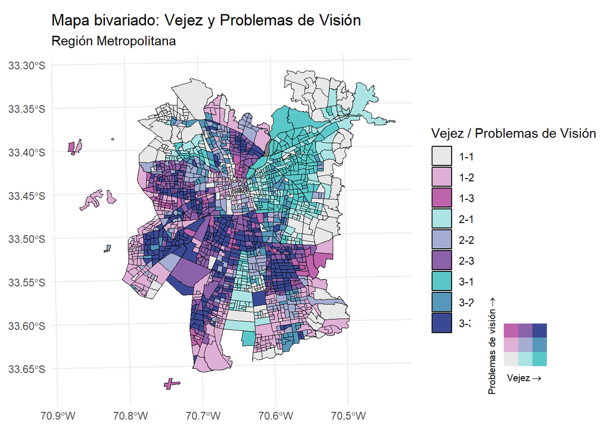

# Analisis

Los mayores porcentajes de problemas visuales se acercan al 30%, lo que resulta considerablemente peligroso para el estilo de vida urbano. Por otro lado, los valores mínimos rondan el 2%, por lo que se puede afirmar que se trata de un problema presente a distintas escalas en toda la región.

La zona oeste presenta altos índices de problemas visuales, especialmente entre los adultos mayores, lo que puede deber a déficits en la atención primaria de salud visual de manera general.

La zona centro muestra bajos índices de problemas visuales, especialmente en la comuna de Santiago, lo que se puede explicar por la gran cantidad de centros médicos presentes. Sin embargo, otras comunas cercanas al sur como Estación Central, Pedro Aguirre Cerda, San Miguel y San Joaquín presentan altos índices de problemas visuales, con edades predominantes que varían significativamente. Esto parece denotar importantes diferencias de servicios y acceso a los mismos entre comunas a pesar de su cercanía.

La zona sur es la más heterogénea; por ello, se dividirá en centrosur, sureste y suroeste.

Maipú, en el suroeste, presenta altos índices de problemas visuales, destacándose un sector con alta población mayor (color azul). Más al sur, es la población joven la que presenta estos índices, aunque en menor escala.

En el centrosur, el norte de San Bernardo concentra altos índices tanto de envejecimiento como de problemas visuales, mientras que La Pintana muestra bajas tasas de problemas de visión.

El sureste presenta índices elevados de vejez y problemas visuales en la comuna de La Florida, a diferencia de las comunas aledañas. Además, al este de La Florida, es la población joven la más susceptible a este problema.

En general la zona sur presenta una notable desigualdad incluso dentro de grandes comunas.

# Conclusión

Este estudio permitió correlacionar y visualizar los indices de vejez y problemas visuales de la población de la Región Metropolitana. Se puede concluir que las zonas más afectas son la comuna de Recoleta, toda la zona Oeste y sectores específicos de la zona sur, en los cuales se debería emplear políticas públicas de prevención (para las zonas moradas) y atención médica (para zonas azules).

La microsimulación es de gran ayuda para investigar casos especiales como Maipú o San Bernardo los cuales tienen zonas censales donde agudiza el problema, las cuales pasaría por alto si se estudiara a nivel comuna sin microsimular.

# Bibliografía

Telencuestas. (2023, agosto 29). Población de la Región Metropolitana de Santiago en 2025. Telencuestas. https://telencuestas.com/censos-de-poblacion/chile/2025/metropolitana-de-santiago

Ministerio de Desarrollo Social y Familia. (2020). Índice de prioridad social 2020 [Informe]. Gobierno de Chile. https://www.desarrollosocialyfamilia.gob.cl/storage/docs/boletin_interno/INDICE_DE_PRIORIDAD_SOCIAL_2020(1).pdf